# Data Analysis on the nations GDP

Triaccau

26/6/2021

## Highest nations GDP in 2018

First, it might be interesting to look at the ranking of the top 10 nations with the highest GDP. It is not a surprise that China, USA and India are at the top of this specific ranking. Asia is the most represented continent on this list, with 5 nations. Europe is in second place, thanks to France, Germany and the United Kingdom. Instead, no nation representing the African continent.

```
## # A tibble: 10 x 4
## # Groups:   Entity [10]
##    Entity         Code   Year     GDP
##    <chr>          <chr> <int>   <dbl>
##  1 China          CHN    2018 1.82e13
##  2 United States  USA    2018 1.81e13
##  3 India          IND    2018 8.84e12
##  4 Japan          JPN    2018 4.87e12
##  5 Germany        DEU    2018 3.89e12
##  6 Russia         RUS    2018 3.61e12
##  7 Indonesia      IDN    2018 3.08e12
##  8 Brazil         BRA    2018 2.97e12
##  9 France         FRA    2018 2.58e12
## 10 United Kingdom GBR    2018 2.54e12
```

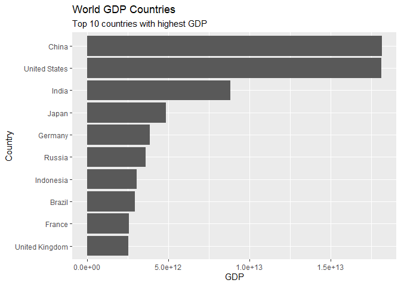

## Regions trend among years (1950 - 2018)

Another interesting aspect is the growth of GDP by different region since 1950 to 2018. In this case is possible to observe the huge increasing of home production in the east Asia region, western Europe, south and south east Asia and western offshoots (eg USA, Canada, Australia)

[figure not shown]

## Highest nations GDP growth along years

At the end, we can analyze the nations with the hugest increasing percent level of GDP during the period 1950 - 2018. The ranking is dominated by middle east countries. As it is possible to see UAE, Oman and Qatar are on the top; Naturally, the discovery of petrol in this territories represent the main motive of these great rate of increasing.

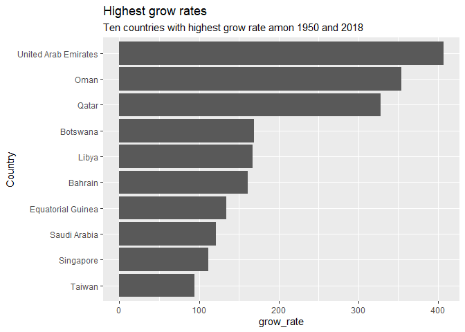